# Machine Learning II Capstone Project

## Objective

The goal for this project is to create a model that could be used in an application that recommends specific airlines to users based on preferences they provide. The model will be trained on a dataset of user reviews that include both textual feedback as well as categorical ratings. The primary machine learning techniques used will be a combination of regression analysis and sentiment analysis. The evaluation will be determined based on how accurately the model can predict whether the sentiment and associated rating scores result in a recommendation of the airline.

The dataset was obtained from Kaggle at https://www.kaggle.com/datasets/anandshaw2001/airlines-reviews-and-rating

### Load the dataset

```python
import pandas as pd
import numpy as np
from textblob import TextBlob

# Load the dataset
file_path = 'airlines-reviews-and-rating.csv'
data = pd.read_csv(file_path)
```

### Cleaning the data

```python
# Handle missing values for ratings
rating_columns = ['Seat Comfort', 'Cabin Staff Service', 'Ground Service', 'Food & Beverages', 'Wifi & Connectivity', 'Inflight Entertainment']
for column in rating_columns:
    data[column] = data[column].replace(np.nan, data[column].mean())

# Clean and analyze sentiment in reviews
data['Cleaned Reviews'] = data['Users Reviews'].str.replace(r"✅Trip Verified\| |Not Verified\| ", "", regex=True)
data['Sentiment Score'] = data['Cleaned Reviews'].apply(lambda x: TextBlob(x).sentiment.polarity)
```

The text in reviews was cleaned to remove artifacts that are irrelevant to sentiment analysis. This helps ensure that the sentiment analysis focuses purely on the textual content that reflects the customer's opinions and feelings. TextBlob provides a straightforward way to obtain sentiment scores because it utilizes a pre-trained model.

### Exploring the cleaned data

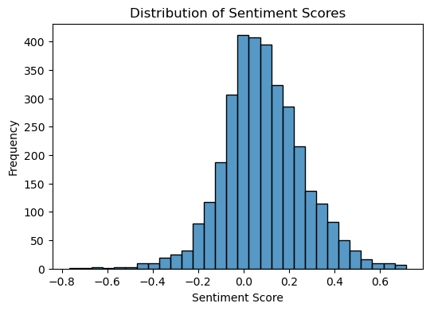

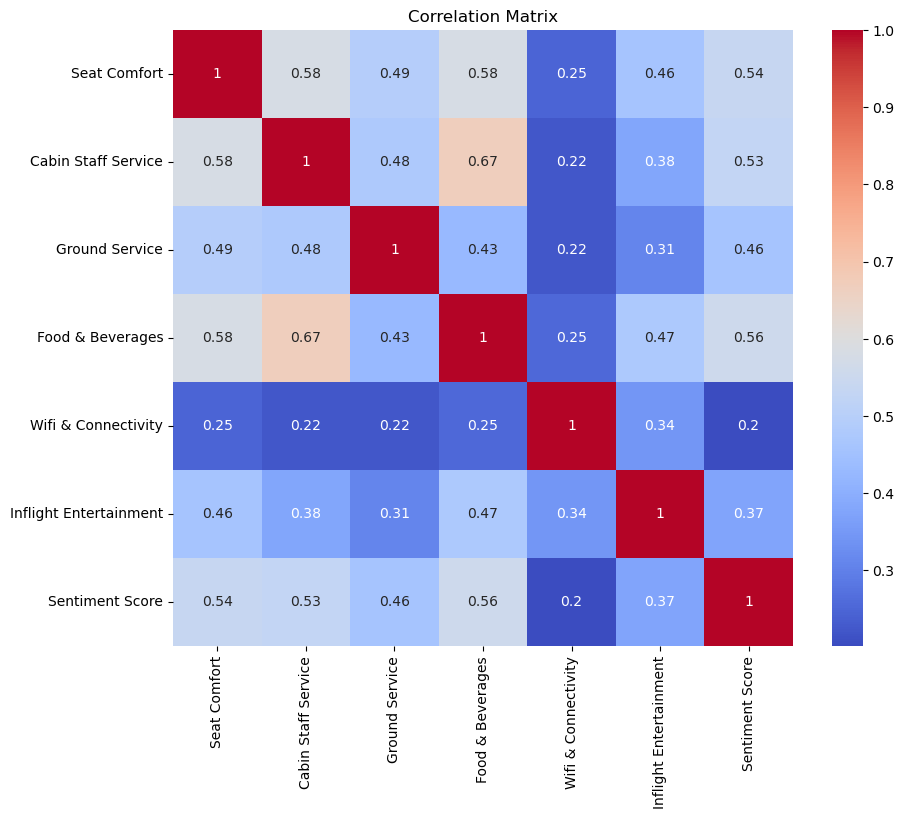

```python
import matplotlib.pyplot as plt
import seaborn as sns

# Distribution of sentiment scores
plt.figure(figsize=(6, 4))
sns.histplot(data['Sentiment Score'], bins=30, kde=False)
plt.title('Distribution of Sentiment Scores')
plt.xlabel('Sentiment Score')
plt.ylabel('Frequency')
plt.show()

# Correlation matrix
plt.figure(figsize=(10, 8))
sns.heatmap(data[rating_columns + ['Sentiment Score', 'Recommended']].corr(), annot=True, cmap='coolwarm')
plt.title('Correlation Matrix')
plt.show()
```

### Analysis & Explanation

The sentiment distribution chart shows the range of sentiment scores. These scores have a central tendency slightly skewed towards positive sentiment.

The correlation matrix visualizes the relationships between different aspects of airline service reviews and the sentiment scores of those reviews:

Values near 1 or -1 indicate a strong positive or negative correlation. Values near 0 suggest little to no linear relationship between the variables.

Some notable correlations from the matrix:

- Seat Comfort and Cabin Staff Service: A correlation of 0.58 suggests a moderately strong positive relationship, meaning higher ratings in seat comfort often coincide with higher ratings for cabin staff service.
- Food & Beverages and Cabin Staff Service: The correlation of 0.67 is quite strong, indicating that good service from the cabin staff often goes hand-in-hand with positive ratings for food and beverages.

There are 3 categories with high correlations to the sentiment scores:

- Seat Comfort: 0.54
- Cabin Staff Service: 0.53
- Food & Beverages: 0.56

These correlations indicate that a customer is more likely to write a positive review when seat comfort, cabin staff service, and food & beverage service is viewed positively. An airline could use this information as reasoning to consider improving the overall quality of those 3 key service areas.

## Model 1

For this first model, a Logistic Regression approach was used because it is commonly used for binary classification problems. This model was intended as a baseline to establish initial performance metrics. A standard 80-20 train-test split was used. The results are visualized with confusion matrices and classification reports to provide an initial assessment of the model's accuracy, precision, recall, and F1 scores, enabling quick identification of areas for improvement.

The key purpose of this model would be for identifying whether a customer would recommend the airline based on the set of metrics comprised of the rating columns and sentiment score.

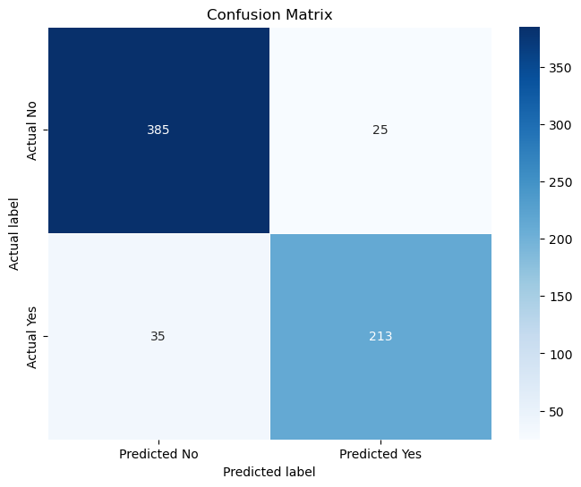

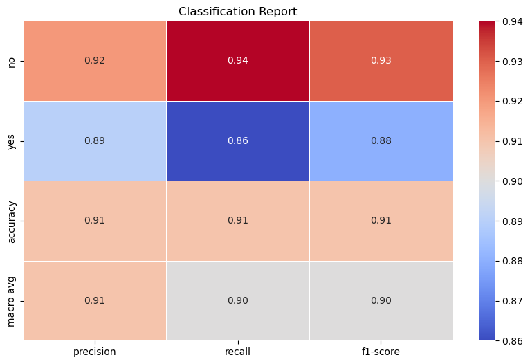

```python
from sklearn.model_selection import train_test_split
from sklearn.linear_model import LogisticRegression
from sklearn.metrics import classification_report, confusion_matrix

# Prepare features and target
X = data[rating_columns + ['Sentiment Score']]
y = data['Recommended']

# Split data
X_train, X_test, y_train, y_test = train_test_split(X, y, test_size=0.2, random_state=42)

# Train the model
model1 = LogisticRegression()
model1.fit(X_train, y_train)

# Predictions
predictions1 = model1.predict(X_test)

# Evaluate the model
# Confusion Matrix Visualization
cm = confusion_matrix(y_test, predictions1)
plt.figure(figsize=(8, 6))
sns.heatmap(cm, annot=True, fmt="d", linewidths=.5, cmap='Blues', xticklabels=['Predicted No', 'Predicted Yes'], yticklabels=['Actual No', 'Actual Yes'])
plt.title('Confusion Matrix')
plt.ylabel('Actual label')
plt.xlabel('Predicted label')
plt.show()

# Classification Report Conversion and Visualization
report = classification_report(y_test, predictions1, output_dict=True)
df_report = pd.DataFrame(report).transpose()
df_report = df_report.round(2)
plt.figure(figsize=(10, 6))
sns.heatmap(df_report.iloc[:-1, :-1], annot=True, cmap='coolwarm', fmt=".2f", linewidths=.5)
plt.title('Classification Report')
plt.show()
```

### Analysis

These appear to be very good results so far, with the model correctly predicting whether a review is positive or negative about 91% of the time.

## Model 2

The second model uses a more complex machine learning approach using RandomForestClassifier with polynomial feature transformations to capture nonlinear relationships between features. This was chosen because it is good for handling potential overfitting issues better than many other algorithms, especially in this case where there are many features with various interactions.

PolynomialFeatures was set to degree 2 to explore interactions between features, ideally enhancing the model's ability to distinguish between the classes more effectively.

A pipeline was utilized to streamline the process of applying transformations and fitting the classifier. GridSearchCV was conducted to optimize RandomForest parameters such as the number of estimators and the depth of trees, ensuring the most effective combination for model performance.

```
Fitting 5 folds for each of 24 candidates, totalling 120 fits
```

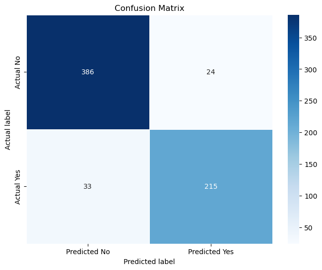

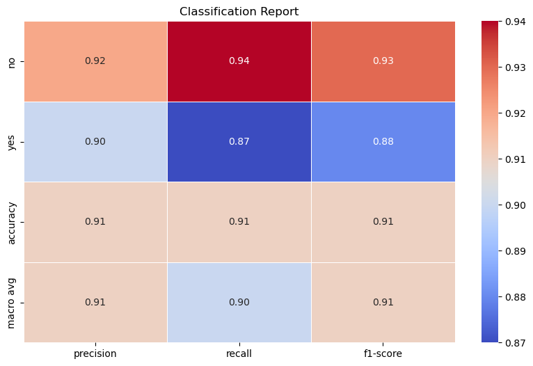

```python
from sklearn.ensemble import RandomForestClassifier
from sklearn.preprocessing import PolynomialFeatures
from sklearn.pipeline import Pipeline
from sklearn.model_selection import GridSearchCV

# Feature engineering
poly = PolynomialFeatures(degree=2, include_bias=False)

# Model
rf = RandomForestClassifier(random_state=42)

# Create a pipeline
pipeline = Pipeline([
    ('poly', poly),
    ('rf', rf)
])

# Parameter grid for Grid Search
param_grid = {
    'rf__n_estimators': [100, 200],
    'rf__max_depth': [10, 20, None],
    'rf__min_samples_split': [2, 5],
    'rf__min_samples_leaf': [1, 2]
}

# Grid search with cross-validation
grid_search = GridSearchCV(pipeline, param_grid, cv=5, scoring='accuracy', verbose=1)

# Fit model
grid_search.fit(X_train, y_train)

model2 = grid_search.best_estimator_

# Predictions
predictions2 = model2.predict(X_test)

# Evaluate the model
# Confusion Matrix Visualization
cm = confusion_matrix(y_test, predictions2)
plt.figure(figsize=(8, 6))
sns.heatmap(cm, annot=True, fmt="d", linewidths=.5, cmap='Blues', xticklabels=['Predicted No', 'Predicted Yes'], yticklabels=['Actual No', 'Actual Yes'])
plt.title('Confusion Matrix')
plt.ylabel('Actual label')
plt.xlabel('Predicted label')
plt.show()

# Classification Report Conversion and Visualization
report = classification_report(y_test, predictions2, output_dict=True)
df_report = pd.DataFrame(report).transpose()
df_report = df_report.round(2)
plt.figure(figsize=(10, 6))
sns.heatmap(df_report.iloc[:-1, :-1], annot=True, cmap='coolwarm', fmt=".2f", linewidths=.5)
plt.title('Classification Report')
plt.show()
```

### Analysis

Very very small gains here, barely even 1% but still an improvement. The trade off in the complexity of the model may not be worth the gain however. While it was still relatively short, it did take 20x longer to run than model 1.

## Comparison

The output below shows the small improvements from model 1 to 2.

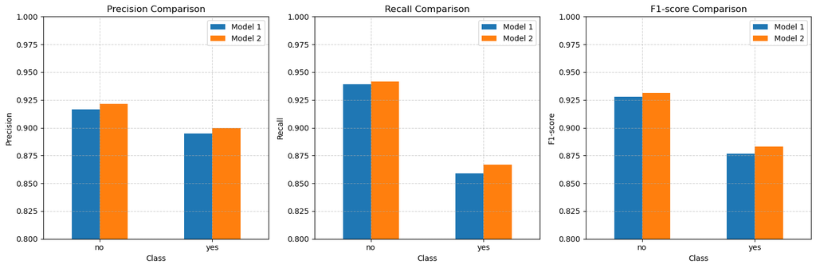

```python
report1 = classification_report(y_test, predictions1, output_dict=True)
report2 = classification_report(y_test, predictions2, output_dict=True)

# Convert reports to DataFrames
df_report1 = pd.DataFrame(report1).transpose()
df_report2 = pd.DataFrame(report2).transpose()

# Prepare data for plotting
metrics = ['precision', 'recall', 'f1-score']
categories = ['no', 'yes']

# Initialize the matplotlib figure
plt.figure(figsize=(15, 5))

# Create a bar plot for each category and metric
for i, metric in enumerate(metrics):
    plt.subplot(1, len(metrics), i+1)
    scores = {
        'Model 1': df_report1.loc[categories, metric],
        'Model 2': df_report2.loc[categories, metric]
    }
    df_scores = pd.DataFrame(scores)

    # Plotting
    df_scores.plot(kind='bar', ax=plt.gca(), color=['#1f77b4', '#ff7f0e'])
    plt.title(f'{metric.capitalize()} Comparison')
    plt.ylabel(metric.capitalize())
    plt.xlabel('Class')
    plt.xticks(rotation=0)
    plt.ylim(0.8, 1)
    plt.grid(True, linestyle='--', alpha=0.6)

plt.tight_layout()
plt.show()
```

## Model 3

Going to try a neural network with Tensorflow for this next model.

A neural network approach is ideal because of its ability to model complex relationships through deep learning techniques. In large datasets neural networks can better detect intricate patterns through layers of neurons which makes them suitable for this predictive task with diverse input features.

### Key Choices

#### Label Encoding and Data Scaling

- LabelEncoder was used to transform string labels into integers which is a necessary preprocessing step for neural networks requiring numeric input.
- StandardScaler standardizes the features by removing the mean and scaling to unit variance. This normalization is important to help speed up the learning process by ensuring that all input features contribute equally.

#### Neural Network Architecture

- The model was constructed using Sequential from TF Keras which is suitable for a straightforward feed-forward network.
- Dense layers with ReLU activation function were chosen for their non-linear properties, allowing the model to learn non-linear relationships in the data.
- Dropout layers were included to provide regularization for helping to prevent overfitting by randomly dropping units during training.
- Sigmoid was used in the output layer which is appropriate for binary classification.

#### Compilation and Training

- The model was compiled with the Adam optimizer and binary_crossentropy loss, which are standard choices for binary classification.
- The training process monitors the accuracy and validation metrics to gauge performance and avoid overfitting.

[output not shown]

```
Loss: 0.22999797761440277, Accuracy: 0.9072948098182678
```

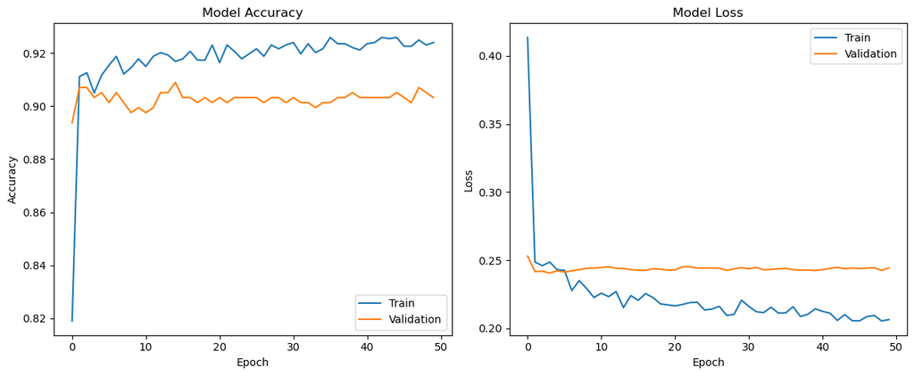

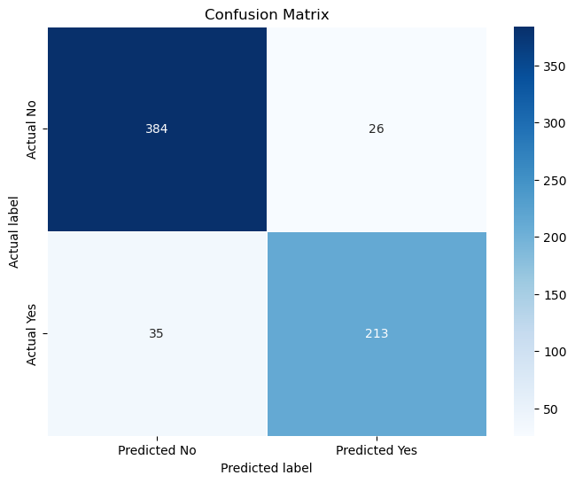

```
              precision    recall  f1-score   support

          No       0.92      0.94      0.93       410
         Yes       0.89      0.86      0.87       248

    accuracy                           0.91       658
   macro avg       0.90      0.90      0.90       658
weighted avg       0.91      0.91      0.91       658
```

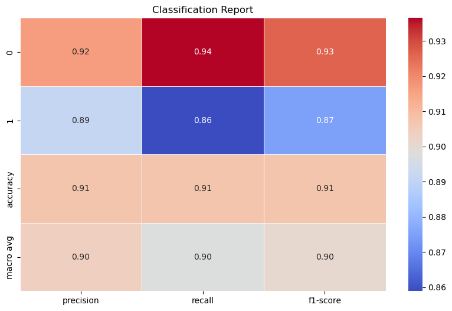

```python
from sklearn.preprocessing import StandardScaler
import tensorflow as tf
from tensorflow.keras.models import Sequential
from tensorflow.keras.layers import Dense, Dropout
from sklearn.preprocessing import LabelEncoder

# Convert string labels to integers
encoder = LabelEncoder()
y_train = encoder.fit_transform(y_train)
y_test = encoder.transform(y_test)

# Scale values appropriately
scaler = StandardScaler()
X_train_scaled = scaler.fit_transform(X_train)
X_test_scaled = scaler.transform(X_test)

model3 = Sequential([
    Dense(128, activation='relu', input_shape=(X_train_scaled.shape[1],)),
    Dropout(0.5),
    Dense(64, activation='relu'),
    Dropout(0.5),
    Dense(1, activation='sigmoid')
])

model3.compile(optimizer='adam',
               loss='binary_crossentropy',
               metrics=['accuracy'])

history = model3.fit(X_train_scaled, y_train, epochs=50, validation_split=0.2)

loss, accuracy = model3.evaluate(X_test_scaled, y_test)
print(f"Loss: {loss}, Accuracy: {accuracy}")

plt.figure(figsize=(12, 5))

# Plot training & validation accuracy
plt.subplot(1, 2, 1)
plt.plot(history.history['accuracy'], label='Train')
plt.plot(history.history['val_accuracy'], label='Validation')
plt.title('Model Accuracy')
plt.xlabel('Epoch')
plt.ylabel('Accuracy')
plt.legend()

# Plot training & validation loss
plt.subplot(1, 2, 2)
plt.plot(history.history['loss'], label='Train')
plt.plot(history.history['val_loss'], label='Validation')
plt.title('Model Loss')
plt.xlabel('Epoch')
plt.ylabel('Loss')
plt.legend()

plt.tight_layout()
plt.show()

predictions_prob = model3.predict(X_test_scaled)

predictions3 = (predictions_prob > 0.5).astype(int)

# Generate confusion matrix
cm = confusion_matrix(y_test, predictions3)

# Plot confusion matrix
plt.figure(figsize=(8, 6))
sns.heatmap(cm, annot=True, fmt="d", linewidths=.5, cmap='Blues', xticklabels=['Predicted No', 'Predicted Yes'], yticklabels=['Actual No', 'Actual Yes'])
plt.title('Confusion Matrix')
plt.ylabel('Actual label')
plt.xlabel('Predicted label')
plt.show()

# Generate and print classification report
report = classification_report(y_test, predictions3, target_names=['No', 'Yes'])
print(report)

# Convert report to DataFrame
report_dict = classification_report(y_test, predictions3, output_dict=True)
df_report = pd.DataFrame(report_dict).transpose()

# Visualize the classification report
plt.figure(figsize=(10, 6))
sns.heatmap(df_report.iloc[:-1, :-1], annot=True, cmap='coolwarm', fmt=".2f", linewidths=.5)
plt.title('Classification Report')
plt.show()
```

## Analysis

The gap between training and validation accuracy suggests a small amount of overfitting. Although the model is performing well on the training data, it didn't perform quite as well on the validation data. The stability of validation accuracy and loss is a positive sign, further training might not significantly improve performance and the model has reached a point of diminishing returns.

The confusion matrix and classification reports show only very minor differences from the previous models, not a notable improvement.

```python
# Ensure all predictions are converted to integers for chart
predictions1 = np.where(predictions1 == 'yes', 1, 0) if predictions1.dtype == 'O' else predictions1
predictions2 = np.where(predictions2 == 'yes', 1, 0) if predictions2.dtype == 'O' else predictions2
predictions3 = np.where(predictions3 == 'yes', 1, 0) if predictions3.dtype == 'O' else predictions3
```

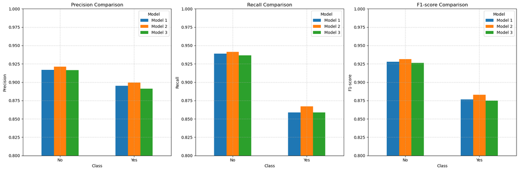

```
Classification Report for Model 1:
              precision    recall  f1-score     support
0              0.916667  0.939024  0.927711  410.000000
1              0.894958  0.858871  0.876543  248.000000
accuracy       0.908815  0.908815  0.908815    0.908815
macro avg      0.905812  0.898948  0.902127  658.000000
weighted avg   0.908485  0.908815  0.908426  658.000000

Classification Report for Model 2:
              precision    recall  f1-score     support
0              0.921241  0.941463  0.931242  410.000000
1              0.899582  0.866935  0.882957  248.000000
accuracy       0.913374  0.913374  0.913374    0.913374
macro avg      0.910411  0.904199  0.907100  658.000000
weighted avg   0.913078  0.913374  0.913044  658.000000

Classification Report for Model 3:
              precision    recall  f1-score     support
0              0.916468  0.936585  0.926417  410.000000
1              0.891213  0.858871  0.874743  248.000000
accuracy       0.907295  0.907295  0.907295    0.907295
macro avg      0.903841  0.897728  0.900580  658.000000
weighted avg   0.906949  0.907295  0.906941  658.000000

Summary of Metrics Across Models:
              Model 1 Precision  Model 1 Recall  Model 1 F1-Score  \
0                      0.916667        0.939024          0.927711
1                      0.894958        0.858871          0.876543
accuracy               0.908815        0.908815          0.908815
macro avg              0.905812        0.898948          0.902127
weighted avg           0.908485        0.908815          0.908426

              Model 2 Precision  Model 2 Recall  Model 2 F1-Score  \
0                      0.921241        0.941463          0.931242
1                      0.899582        0.866935          0.882957
accuracy               0.913374        0.913374          0.913374
macro avg              0.910411        0.904199          0.907100
weighted avg           0.913078        0.913374          0.913044

              Model 3 Precision  Model 3 Recall  Model 3 F1-Score
0                      0.916468        0.936585          0.926417
1                      0.891213        0.858871          0.874743
accuracy               0.907295        0.907295          0.907295
macro avg              0.903841        0.897728          0.900580
weighted avg           0.906949        0.907295          0.906941
```

```python
report1 = classification_report(y_test, predictions1, output_dict=True)
df_report1 = pd.DataFrame(report1).transpose()

report2 = classification_report(y_test, predictions2, output_dict=True)
df_report2 = pd.DataFrame(report2).transpose()

report3 = classification_report(y_test, predictions3, output_dict=True)
df_report3 = pd.DataFrame(report3).transpose()

metrics = ['precision', 'recall', 'f1-score']
classes = ['0', '1']

plt.figure(figsize=(18, 6))

# Iterate over each metric to create a subplot for each
for i, metric in enumerate(metrics):
    plt.subplot(1, len(metrics), i+1)
    # Extract the specific metric for both classes from each model's report
    scores = {
        'Model 1': df_report1.loc[classes, metric],
        'Model 2': df_report2.loc[classes, metric],
        'Model 3': df_report3.loc[classes, metric]
    }
    df_scores = pd.DataFrame(scores)
    # Plotting the scores
    ax = df_scores.plot(kind='bar', ax=plt.gca(), color=['#1f77b4', '#ff7f0e', '#2ca02c'])
    plt.title(f'{metric.capitalize()} Comparison')
    plt.ylabel(metric.capitalize())
    plt.xlabel('Class')
    plt.xticks(ticks=np.arange(len(classes)), labels=['No', 'Yes'], rotation=0)
    plt.ylim(0.8, 1)
    plt.legend(title="Model")
    plt.grid(True, linestyle='--', alpha=0.6)

plt.tight_layout()
plt.show()

print("Classification Report for Model 1:")
print(df_report1)
print("\nClassification Report for Model 2:")
print(df_report2)
print("\nClassification Report for Model 3:")
print(df_report3)

summary = pd.DataFrame({
    'Model 1 Precision': df_report1['precision'],
    'Model 1 Recall': df_report1['recall'],
    'Model 1 F1-Score': df_report1['f1-score'],
    'Model 2 Precision': df_report2['precision'],
    'Model 2 Recall': df_report2['recall'],
    'Model 2 F1-Score': df_report2['f1-score'],
    'Model 3 Precision': df_report3['precision'],
    'Model 3 Recall': df_report3['recall'],
    'Model 3 F1-Score': df_report3['f1-score']
})

print("\nSummary of Metrics Across Models:")
print(summary)
```

# Analysis

## Overall Model Evaluation

This analysis indicates that **Model 2** consistently outperforms the other models across most metrics.

# Model 4

A more advanced approach would be to use a combination of CNN and LSTM models. The CNN will be responsible for extracting spatial features from the structured ratings data while the LSTM will process sequential input from sentiment scores.

```python
from tensorflow.keras.models import Model
from tensorflow.keras.layers import Input, Conv1D, LSTM, GlobalMaxPooling1D, Concatenate, Reshape
from tensorflow.keras.optimizers import Adam

# Ensure the target is numeric
data['Recommended'] = data['Recommended'].replace({'yes': 1, 'no': 0})

# Prepare features and target
X = data[rating_columns + ['Sentiment Score']]
y = data['Recommended']

# Split data
X_train, X_test, y_train, y_test = train_test_split(X, y, test_size=0.2, random_state=42)

# Scale the features
scaler = StandardScaler()
X_train_scaled = scaler.fit_transform(X_train)
X_test_scaled = scaler.transform(X_test)

# Model architecture
rating_input = Input(shape=(len(rating_columns),))
x = Dense(len(rating_columns), activation='relu')(rating_input)
x = Reshape((len(rating_columns), 1))(x)
x = Conv1D(64, kernel_size=3, activation='relu')(x)
x = GlobalMaxPooling1D()(x)
cnn_output = Dense(32, activation='relu')(x)

sentiment_input = Input(shape=(1,))
y = Dense(32, activation='relu')(sentiment_input)
y = Reshape((1, 32))(y)
y = LSTM(32)(y)
rnn_output = Dense(32, activation='relu')(y)

combined = Concatenate()([cnn_output, rnn_output])
z = Dense(64, activation='relu')(combined)
z = Dropout(0.5)(z)
output = Dense(1, activation='sigmoid')(z)

model4 = Model(inputs=[rating_input, sentiment_input], outputs=output)
model4.compile(optimizer=Adam(learning_rate=0.001), loss='binary_crossentropy', metrics=['accuracy'])

# Fit the model
model4.fit([X_train_scaled[:, :len(rating_columns)], X_train_scaled[:, -1].reshape(-1, 1)], y_train,
           validation_data=([X_test_scaled[:, :len(rating_columns)], X_test_scaled[:, -1].reshape(-1, 1)], y_test),
           epochs=100, batch_size=32)
```

```
<keras.src.callbacks.History at 0x15371a010>
```

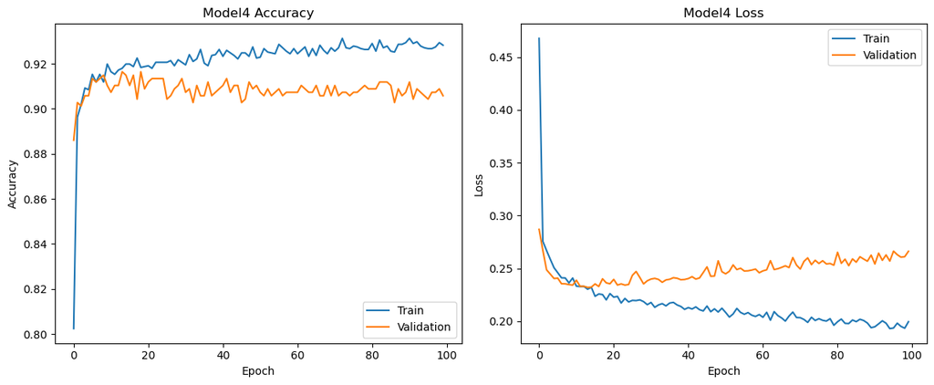

```python
# Retrieve history data
history_data = model4.history.history

# Plotting the training & validation accuracy
plt.figure(figsize=(12, 5))
plt.subplot(1, 2, 1)
plt.plot(history_data['accuracy'], label='Train')
plt.plot(history_data['val_accuracy'], label='Validation')
plt.title('Model4 Accuracy')
plt.xlabel('Epoch')
plt.ylabel('Accuracy')
plt.legend()

# Plotting the training & validation loss
plt.subplot(1, 2, 2)
plt.plot(history_data['loss'], label='Train')
plt.plot(history_data['val_loss'], label='Validation')
plt.title('Model4 Loss')
plt.xlabel('Epoch')
plt.ylabel('Loss')
plt.legend()

plt.tight_layout()
plt.show()
```

## Model4 Analysis

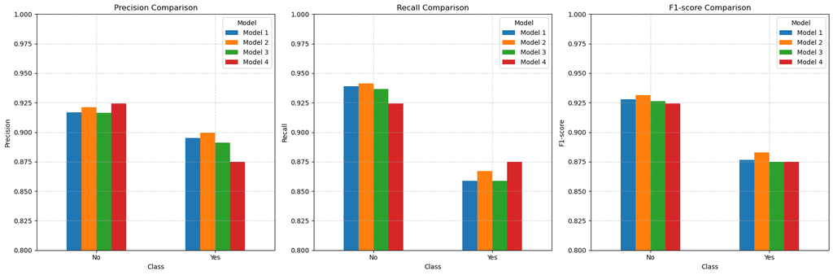

```
Classification Report for Model 1:
              precision    recall  f1-score     support
0              0.916667  0.939024  0.927711  410.000000
1              0.894958  0.858871  0.876543  248.000000
accuracy       0.908815  0.908815  0.908815    0.908815
macro avg      0.905812  0.898948  0.902127  658.000000
weighted avg   0.908485  0.908815  0.908426  658.000000

Classification Report for Model 2:
              precision    recall  f1-score     support
0              0.921241  0.941463  0.931242  410.000000
1              0.899582  0.866935  0.882957  248.000000
accuracy       0.913374  0.913374  0.913374    0.913374
macro avg      0.910411  0.904199  0.907100  658.000000
weighted avg   0.913078  0.913374  0.913044  658.000000

Classification Report for Model 3:
              precision    recall  f1-score     support
0              0.916468  0.936585  0.926417  410.000000
1              0.891213  0.858871  0.874743  248.000000
accuracy       0.907295  0.907295  0.907295    0.907295
macro avg      0.903841  0.897728  0.900580  658.000000
weighted avg   0.906949  0.907295  0.906941  658.000000

Classification Report for Model 4:
              precision    recall  f1-score     support
0              0.924390  0.924390  0.924390  410.000000
1              0.875000  0.875000  0.875000  248.000000
accuracy       0.905775  0.905775  0.905775    0.905775
macro avg      0.899695  0.899695  0.899695  658.000000
weighted avg   0.905775  0.905775  0.905775  658.000000

Summary of Metrics Across Models:
              Model 1 Precision  Model 1 Recall  Model 1 F1-Score  \
0                      0.916667        0.939024          0.927711
1                      0.894958        0.858871          0.876543
accuracy               0.908815        0.908815          0.908815
macro avg              0.905812        0.898948          0.902127
weighted avg           0.908485        0.908815          0.908426

              Model 2 Precision  Model 2 Recall  Model 2 F1-Score  \
0                      0.921241        0.941463          0.931242
1                      0.899582        0.866935          0.882957
accuracy               0.913374        0.913374          0.913374
macro avg              0.910411        0.904199          0.907100
weighted avg           0.913078        0.913374          0.913044

              Model 3 Precision  Model 3 Recall  Model 3 F1-Score  \
0                      0.916468        0.936585          0.926417
1                      0.891213        0.858871          0.874743
accuracy               0.907295        0.907295          0.907295
macro avg              0.903841        0.897728          0.900580
weighted avg           0.906949        0.907295          0.906941

              Model 4 Precision  Model 4 Recall  Model 4 F1-Score
0                      0.924390        0.924390          0.924390
1                      0.875000        0.875000          0.875000
accuracy               0.905775        0.905775          0.905775
macro avg              0.899695        0.899695          0.899695
weighted avg           0.905775        0.905775          0.905775
```

```python
# Split the features for model4 which expects two inputs
test_ratings = X_test_scaled[:, :len(rating_columns)]
test_sentiments = X_test_scaled[:, -1].reshape(-1, 1)

# Prediction with model4
predictions_prob = model4.predict([test_ratings, test_sentiments])
predictions4 = (predictions_prob > 0.5).astype(int)

# Ensure all predictions are handled as integers for comparison in the classification report
predictions1 = np.where(predictions1 == 'yes', 1, 0) if predictions1.dtype == 'O' else predictions1
predictions2 = np.where(predictions2 == 'yes', 1, 0) if predictions2.dtype == 'O' else predictions2
predictions3 = np.where(predictions3 == 'yes', 1, 0) if predictions3.dtype == 'O' else predictions3
predictions4 = predictions4.flatten()

# Generate classification reports
report1 = classification_report(y_test, predictions1, output_dict=True)
df_report1 = pd.DataFrame(report1).transpose()
report2 = classification_report(y_test, predictions2, output_dict=True)
df_report2 = pd.DataFrame(report2).transpose()
report3 = classification_report(y_test, predictions3, output_dict=True)
df_report3 = pd.DataFrame(report3).transpose()
report4 = classification_report(y_test, predictions4, output_dict=True)
df_report4 = pd.DataFrame(report4).transpose()

# Plot comparison charts
metrics = ['precision', 'recall', 'f1-score']
classes = ['0', '1']
plt.figure(figsize=(18, 6))

# Iterate over each metric to create a subplot for each
for i, metric in enumerate(metrics):
    plt.subplot(1, len(metrics), i+1)
    scores = {
        'Model 1': df_report1.loc[classes, metric],
        'Model 2': df_report2.loc[classes, metric],
        'Model 3': df_report3.loc[classes, metric],
        'Model 4': df_report4.loc[classes, metric]
    }
    df_scores = pd.DataFrame(scores)
    df_scores.plot(kind='bar', ax=plt.gca(), color=['#1f77b4', '#ff7f0e', '#2ca02c', '#d62728'])
    plt.title(f'{metric.capitalize()} Comparison')
    plt.ylabel(metric.capitalize())
    plt.xlabel('Class')
    plt.xticks(ticks=np.arange(len(classes)), labels=['No', 'Yes'], rotation=0)
    plt.ylim(0.8, 1)
    plt.legend(title="Model")
    plt.grid(True, linestyle='--', alpha=0.6)

plt.tight_layout()
plt.show()

# Print classification reports
print("Classification Report for Model 1:")
print(df_report1)
print("\nClassification Report for Model 2:")
print(df_report2)
print("\nClassification Report for Model 3:")
print(df_report3)
print("\nClassification Report for Model 4:")
print(df_report4)

# Summary of metrics across models
summary = pd.DataFrame({
    'Model 1 Precision': df_report1['precision'],
    'Model 1 Recall': df_report1['recall'],
    'Model 1 F1-Score': df_report1['f1-score'],
    'Model 2 Precision': df_report2['precision'],
    'Model 2 Recall': df_report2['recall'],
    'Model 2 F1-Score': df_report2['f1-score'],
    'Model 3 Precision': df_report3['precision'],
    'Model 3 Recall': df_report3['recall'],
    'Model 3 F1-Score': df_report3['f1-score'],
    'Model 4 Precision': df_report4['precision'],
    'Model 4 Recall': df_report4['recall'],
    'Model 4 F1-Score': df_report4['f1-score']
})

print("\nSummary of Metrics Across Models:")
print(summary)
```

# Analysis

Model 4 has a slight edge in a couple categories but also worse in others. Going to try now to make some improvements.

- Advanced Layer Configurations: Increasing the depth and complexity to better capture the data's nuances.
- Regularization Techniques: Introduce L2 regularization methods to prevent overfitting.
- Learning Rate Scheduling: Implement learning rate scheduling to improve convergence during training.

```python
from tensorflow.keras.regularizers import l2
from tensorflow.keras.optimizers import Adam
from tensorflow.keras.callbacks import LearningRateScheduler

# Function to update the learning rate
def scheduler(epoch, lr):
    if epoch < 10:
        return lr
    else:
        return lr * np.exp(-0.1)

# Prepare data preprocessing
scaler = StandardScaler()
X_train_scaled = scaler.fit_transform(X_train)
X_test_scaled = scaler.transform(X_test)

# Model architecture with additional complexity and L2 regularization
rating_input = Input(shape=(len(rating_columns),))
x = Dense(len(rating_columns), activation='relu', kernel_regularizer=l2(0.01))(rating_input)
x = Reshape((len(rating_columns), 1))(x)
x = Conv1D(128, kernel_size=3, activation='relu', kernel_regularizer=l2(0.01))(x)  # Increased the number of filters
x = GlobalMaxPooling1D()(x)
cnn_output = Dense(64, activation='relu', kernel_regularizer=l2(0.01))(x)  # Increased the units

sentiment_input = Input(shape=(1,))
y = Dense(64, activation='relu', kernel_regularizer=l2(0.01))(sentiment_input)  # Increased the units
y = Reshape((1, 64))(y)  # Adjusted the reshape to match the new unit size
y = LSTM(64, return_sequences=True, kernel_regularizer=l2(0.01))(y)  # Increased the units and added return_sequences
y = GlobalMaxPooling1D()(y)  # Added pooling to LSTM output
rnn_output = Dense(64, activation='relu', kernel_regularizer=l2(0.01))(y)

combined = Concatenate()([cnn_output, rnn_output])
z = Dense(128, activation='relu', kernel_regularizer=l2(0.01))(combined)  # Increased the units
z = Dropout(0.5)(z)
output = Dense(1, activation='sigmoid')(z)

model5 = Model(inputs=[rating_input, sentiment_input], outputs=output)
model5.compile(optimizer=Adam(learning_rate=0.001), loss='binary_crossentropy', metrics=['accuracy'])

# Fit the model with LearningRateScheduler
history_model5 = model5.fit([X_train_scaled[:, :len(rating_columns)], X_train_scaled[:, -1].reshape(-1, 1)], y_train,
                            validation_data=([X_test_scaled[:, :len(rating_columns)], X_test_scaled[:, -1].reshape(-1, 1)], y_test),
                            epochs=100, batch_size=32, callbacks=[LearningRateScheduler(scheduler)])
```

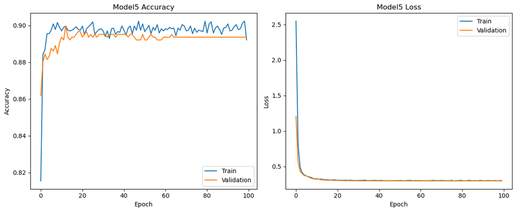

```python
# Plotting the training & validation accuracy
plt.figure(figsize=(12, 5))
plt.subplot(1, 2, 1)
plt.plot(history_model5.history['accuracy'], label='Train')
plt.plot(history_model5.history['val_accuracy'], label='Validation')
plt.title('Model5 Accuracy')
plt.xlabel('Epoch')
plt.ylabel('Accuracy')
plt.legend()

# Plotting the training & validation loss
plt.subplot(1, 2, 2)
plt.plot(history_model5.history['loss'], label='Train')
plt.plot(history_model5.history['val_loss'], label='Validation')
plt.title('Model5 Loss')
plt.xlabel('Epoch')
plt.ylabel('Loss')
plt.legend()

plt.tight_layout()
plt.show()
```

# Model5 Analysis

Accuracy

- The training accuracy appears relatively stable throughout the epochs, slightly increasing and then leveling off.
- The validation accuracy shows a rapid improvement in the initial epochs, which stabilizes soon after. The flat line in the latter third of the epochs indicates that the model has reached a plateau in learning from the validation data, it's probably not gaining additional significant insights from further training.

Loss

- Both training and validation loss decrease sharply at the start and then flatten out, which is typical and indicates that the major learning changes occur early in the training process. The low stable loss suggests good convergence.

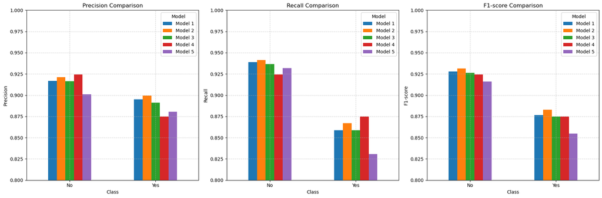

```
Classification Report for Model 1:
              precision    recall  f1-score     support
0              0.916667  0.939024  0.927711  410.000000
1              0.894958  0.858871  0.876543  248.000000
accuracy       0.908815  0.908815  0.908815    0.908815
macro avg      0.905812  0.898948  0.902127  658.000000
weighted avg   0.908485  0.908815  0.908426  658.000000

Classification Report for Model 2:
              precision    recall  f1-score     support
0              0.921241  0.941463  0.931242  410.000000
1              0.899582  0.866935  0.882957  248.000000
accuracy       0.913374  0.913374  0.913374    0.913374
macro avg      0.910411  0.904199  0.907100  658.000000
weighted avg   0.913078  0.913374  0.913044  658.000000

Classification Report for Model 3:
              precision    recall  f1-score     support
0              0.916468  0.936585  0.926417  410.000000
1              0.891213  0.858871  0.874743  248.000000
accuracy       0.907295  0.907295  0.907295    0.907295
macro avg      0.903841  0.897728  0.900580  658.000000
weighted avg   0.906949  0.907295  0.906941  658.000000

Classification Report for Model 4:
              precision    recall  f1-score     support
0              0.924390  0.924390  0.924390  410.000000
1              0.875000  0.875000  0.875000  248.000000
accuracy       0.905775  0.905775  0.905775    0.905775
macro avg      0.899695  0.899695  0.899695  658.000000
weighted avg   0.905775  0.905775  0.905775  658.000000

Classification Report for Model 5:
              precision    recall  f1-score     support
0              0.900943  0.931707  0.916067  410.000000
1              0.880342  0.830645  0.854772  248.000000
accuracy       0.893617  0.893617  0.893617    0.893617
macro avg      0.890643  0.881176  0.885419  658.000000
weighted avg   0.893179  0.893617  0.892965  658.000000

```

[output cut: 20 more lines]

```
weighted avg           0.906949        0.907295          0.906941

              Model 4 Precision  Model 4 Recall  Model 4 F1-Score  \
0                      0.924390        0.924390          0.924390
1                      0.875000        0.875000          0.875000
accuracy               0.905775        0.905775          0.905775
macro avg              0.899695        0.899695          0.899695
weighted avg           0.905775        0.905775          0.905775

              Model 5 Precision  Model 5 Recall  Model 5 F1-Score
0                      0.900943        0.931707          0.916067
1                      0.880342        0.830645          0.854772
accuracy               0.893617        0.893617          0.893617
macro avg              0.890643        0.881176          0.885419
weighted avg           0.893179        0.893617          0.892965
```

```python
# Prediction with model5
predictions_prob = model5.predict([test_ratings, test_sentiments])
predictions5 = (predictions_prob > 0.5).astype(int)

# Ensure all predictions are handled as integers for comparison in the classification report
predictions5 = predictions5.flatten()

# Generate classification report for model5
report5 = classification_report(y_test, predictions5, output_dict=True)
df_report5 = pd.DataFrame(report5).transpose()

# Update the plotting and summary sections to include model5
metrics = ['precision', 'recall', 'f1-score']
classes = ['0', '1']
plt.figure(figsize=(18, 6))

# Iterate over each metric to create a subplot for each
for i, metric in enumerate(metrics):
    plt.subplot(1, len(metrics), i+1)
    scores = {
        'Model 1': df_report1.loc[classes, metric],
        'Model 2': df_report2.loc[classes, metric],
        'Model 3': df_report3.loc[classes, metric],
        'Model 4': df_report4.loc[classes, metric],
        'Model 5': df_report5.loc[classes, metric]
    }
    df_scores = pd.DataFrame(scores)
    df_scores.plot(kind='bar', ax=plt.gca(), color=['#1f77b4', '#ff7f0e', '#2ca02c', '#d62728', '#9467bd'])
    plt.title(f'{metric.capitalize()} Comparison')
    plt.ylabel(metric.capitalize())
    plt.xlabel('Class')
    plt.xticks(ticks=np.arange(len(classes)), labels=['No', 'Yes'], rotation=0)
    plt.ylim(0.8, 1)
    plt.legend(title="Model")
    plt.grid(True, linestyle='--', alpha=0.6)

plt.tight_layout()
plt.show()

# Print classification reports
print("Classification Report for Model 1:")
print(df_report1)
print("\nClassification Report for Model 2:")
print(df_report2)
print("\nClassification Report for Model 3:")
print(df_report3)
print("\nClassification Report for Model 4:")
print(df_report4)
print("\nClassification Report for Model 5:")
print(df_report5)

# Update summary of metrics across models to include model5
summary = pd.DataFrame({
    'Model 1 Precision': df_report1['precision'],
    'Model 1 Recall': df_report1['recall'],
    'Model 1 F1-Score': df_report1['f1-score'],
    'Model 2 Precision': df_report2['precision'],
    'Model 2 Recall': df_report2['recall'],
    'Model 2 F1-Score': df_report2['f1-score'],
    'Model 3 Precision': df_report3['precision'],
    'Model 3 Recall': df_report3['recall'],
    'Model 3 F1-Score': df_report3['f1-score'],
    'Model 4 Precision': df_report4['precision'],
    'Model 4 Recall': df_report4['recall'],
    'Model 4 F1-Score': df_report4['f1-score'],
    'Model 5 Precision': df_report5['precision'],
    'Model 5 Recall': df_report5['recall'],
    'Model 5 F1-Score': df_report5['f1-score']
})

print("\nSummary of Metrics Across Models:")
print(summary)
```

# Analysis

Model5 regressed in the areas that model4 excelled in, an interesting development. Overall, this was the worst performance so far.